# Part I - Ford GoBikes Data Exploration

## by Wafula Abdalah Hassani

- Introduction
- Data Wrangling
- Data Cleaning
- Univariate Exploration
- Bivariate Exploration
- Multivariate Exploration
- Conclusions
- Limitations

## Introduction

> The Dataset consists of ride sharing information regarding 183,412 rides made in a bike sharing system covering San Francisco.

## Preliminary Wrangling

```python
# import all packages and set plots to be embedded inline
import numpy as np
import pandas as pd
import matplotlib.pyplot as plt
import seaborn as sb

%matplotlib inline
```

> Load in your dataset and describe its properties through the questions below. Try and motivate your exploration goals through this section.

```python
# Loading the the Ford GoBikes dataset
bikes_df = pd.read_csv('ford-gobikes.csv')
bikes_df.head()
```

|  | duration_sec | start_time | end_time | start_station_id | start_station_name | start_station_latitude | start_station_longitude | end_station_id | end_station_name | end_station_latitude | end_station_longitude | bike_id | user_type | member_birth_year | member_gender | bike_share_for_all_trip |
| --- | --- | --- | --- | --- | --- | --- | --- | --- | --- | --- | --- | --- | --- | --- | --- | --- |
| 0 | 52185 | 2019-02-28 17:32:10.1450 | 2019-03-01 08:01:55.9750 | 21.0 | Montgomery St BART Station (Market St at 2nd St) | 37.789625 | -122.400811 | 13.0 | Commercial St at Montgomery St | 37.794231 | -122.402923 | 4902 | Customer | 1984.0 | Male | No |
| 1 | 42521 | 2019-02-28 18:53:21.7890 | 2019-03-01 06:42:03.0560 | 23.0 | The Embarcadero at Steuart St | 37.791464 | -122.391034 | 81.0 | Berry St at 4th St | 37.775880 | -122.393170 | 2535 | Customer | NaN | NaN | No |
| 2 | 61854 | 2019-02-28 12:13:13.2180 | 2019-03-01 05:24:08.1460 | 86.0 | Market St at Dolores St | 37.769305 | -122.426826 | 3.0 | Powell St BART Station (Market St at 4th St) | 37.786375 | -122.404904 | 5905 | Customer | 1972.0 | Male | No |
| 3 | 36490 | 2019-02-28 17:54:26.0100 | 2019-03-01 04:02:36.8420 | 375.0 | Grove St at Masonic Ave | 37.774836 | -122.446546 | 70.0 | Central Ave at Fell St | 37.773311 | -122.444293 | 6638 | Subscriber | 1989.0 | Other | No |
| 4 | 1585 | 2019-02-28 23:54:18.5490 | 2019-03-01 00:20:44.0740 | 7.0 | Frank H Ogawa Plaza | 37.804562 | -122.271738 | 222.0 | 10th Ave at E 15th St | 37.792714 | -122.248780 | 4898 | Subscriber | 1974.0 | Male | Yes |

In the above section, we have loaded the dataset of the Ford GoBikes Sharing system which was downloaded manually from the Udacity Webpages. We have also displayed the first 5 rows to view the structure of the data in the dataset

```python
# Displaying the shape (Dimensions)  of the dataset
bikes_df.shape
```

```
(183412, 16)
```

```python
# Displaying the dataset info
bikes_df.info
```

[output not shown]

[output cut: 64 more lines]

```python
# Displaying the dataset data types
bikes_df.dtypes
```

```
duration_sec                 int64
start_time                  object
end_time                    object
start_station_id           float64
start_station_name          object
start_station_latitude     float64
start_station_longitude    float64
end_station_id             float64
end_station_name            object
end_station_latitude       float64
end_station_longitude      float64
bike_id                      int64
user_type                   object
member_birth_year          float64
member_gender               object
bike_share_for_all_trip     object
dtype: object
```

```python
# Checking for missing values
bikes_df.isnull().sum()
```

```
duration_sec                  0
start_time                    0
end_time                      0
start_station_id            197
start_station_name          197
start_station_latitude        0
start_station_longitude       0
end_station_id              197
end_station_name            197
end_station_latitude          0
end_station_longitude         0
bike_id                       0
user_type                     0
member_birth_year          8265
member_gender              8265
bike_share_for_all_trip       0
dtype: int64
```

```python
# Checking for duplicates in the dataset
sum(bikes_df.duplicated())
```

```
0
```

```python
# Checking for unique values
bikes_df.nunique()
```

```
duration_sec                 4752
start_time                 183401
end_time                   183397
start_station_id              329
start_station_name            329
start_station_latitude        334
start_station_longitude       335
end_station_id                329
end_station_name              329
end_station_latitude          335
end_station_longitude         335
bike_id                      4646
user_type                       2
member_birth_year              75
member_gender                   3
bike_share_for_all_trip         2
dtype: int64
```

## Data Cleaning

```python
# Duplicating the dataset
bikes_df_clean = bikes_df.copy()
```

**Issue #1:** Missing values in start_station_id, start_station_name, end_station_id, end_station_name, member_birth_year, member_gender

**Define:** Drop all rows with missing values

**Code:**

```python
# Removing all rows with missing values
bikes_df_clean.dropna(inplace=True)
```

**Test**

```python
bikes_df_clean.isnull().sum()
```

```
duration_sec               0
start_time                 0
end_time                   0
start_station_id           0
start_station_name         0
start_station_latitude     0
start_station_longitude    0
end_station_id             0
end_station_name           0
end_station_latitude       0
end_station_longitude      0
bike_id                    0
user_type                  0
member_birth_year          0
member_gender              0
bike_share_for_all_trip    0
dtype: int64
```

**Issue #2:** Incorrect data types in start_time, end_time, member_birth_year and bike_id

**Define:** Convert the start_time, end_time columns to datetime, bike_id column to string and member_birth_year to int

**Code:**

```python
# Converting start_time, end_time columns
bikes_df_clean['start_time'] = pd.to_datetime(bikes_df_clean['start_time'])
bikes_df_clean['end_time'] = pd.to_datetime(bikes_df_clean['end_time'])
```

```python
# Converting bike_id column
bikes_df_clean['bike_id'] = bikes_df_clean.bike_id.astype(str)
```

```python
# Converting member_birth_year column to int
bikes_df_clean['member_birth_year'] = bikes_df_clean.member_birth_year.astype(int)
```

**Test:**

```python
bikes_df_clean.dtypes
```

```
duration_sec                        int64
start_time                 datetime64[ns]
end_time                   datetime64[ns]
start_station_id                  float64
start_station_name                 object
start_station_latitude            float64
start_station_longitude           float64
end_station_id                    float64
end_station_name                   object
end_station_latitude              float64
end_station_longitude             float64
bike_id                            object
user_type                          object
member_birth_year                   int64
member_gender                      object
bike_share_for_all_trip            object
dtype: object
```

```python
# Extracting the day, month and year columns from the dates fields
import datetime as dt
bikes_df_clean['start_day'] = bikes_df_clean['start_time'].dt.day_name()
bikes_df_clean['start_month'] = bikes_df_clean['start_time'].dt.month_name()
bikes_df_clean['start_hour'] = bikes_df_clean['start_time'].dt.hour
bikes_df_clean['start_hour'] = bikes_df_clean['start_hour'].astype(str)

bikes_df_clean['end_day'] = bikes_df_clean['end_time'].dt.day_name()
bikes_df_clean['end_month'] = bikes_df_clean['end_time'].dt.month_name()
bikes_df_clean['end_hour'] = bikes_df_clean['end_time'].dt.hour
bikes_df_clean['end_hour'] = bikes_df_clean['end_hour'].astype(str)
```

```python
bikes_df_clean.shape
```

```
(174952, 22)
```

```python
bikes_df_clean.head(3)
```

|  | duration_sec | start_time | end_time | start_station_id | start_station_name | start_station_latitude | start_station_longitude | end_station_id | end_station_name | end_station_latitude | ... | user_type | member_birth_year | member_gender | bike_share_for_all_trip | start_day | start_month | start_hour | end_day | end_month | end_hour |
| --- | --- | --- | --- | --- | --- | --- | --- | --- | --- | --- | --- | --- | --- | --- | --- | --- | --- | --- | --- | --- | --- |
| 0 | 52185 | 2019-02-28 17:32:10.145 | 2019-03-01 08:01:55.975 | 21.0 | Montgomery St BART Station (Market St at 2nd St) | 37.789625 | -122.400811 | 13.0 | Commercial St at Montgomery St | 37.794231 | ... | Customer | 1984 | Male | No | Thursday | February | 17 | Friday | March | 8 |
| 2 | 61854 | 2019-02-28 12:13:13.218 | 2019-03-01 05:24:08.146 | 86.0 | Market St at Dolores St | 37.769305 | -122.426826 | 3.0 | Powell St BART Station (Market St at 4th St) | 37.786375 | ... | Customer | 1972 | Male | No | Thursday | February | 12 | Friday | March | 5 |
| 3 | 36490 | 2019-02-28 17:54:26.010 | 2019-03-01 04:02:36.842 | 375.0 | Grove St at Masonic Ave | 37.774836 | -122.446546 | 70.0 | Central Ave at Fell St | 37.773311 | ... | Subscriber | 1989 | Other | No | Thursday | February | 17 | Friday | March | 4 |

3 rows × 22 columns

```python
bikes_df_clean.dtypes
```

```
duration_sec                        int64
start_time                 datetime64[ns]
end_time                   datetime64[ns]
start_station_id                  float64
start_station_name                 object
start_station_latitude            float64
start_station_longitude           float64
end_station_id                    float64
end_station_name                   object
end_station_latitude              float64
end_station_longitude             float64
bike_id                            object
user_type                          object
member_birth_year                   int64
member_gender                      object
bike_share_for_all_trip            object
start_day                          object
start_month                        object
start_hour                         object
end_day                            object
end_month                          object
end_hour                           object
dtype: object
```

### What is the structure of your dataset?

> From the above sections, Initially, the dataset had 183,412 rows and 16 columns which were dropped to 174,952 rows and 22 columns after feature engineering of which are trips recorded in San Francisco Bay Area in 2019. It also contains 6 Floats, 2 datetime, 2 int and 12 object columns.

### What is/are the main feature(s) of interest in your dataset?

> I am interested in exploring the trips durations, time of the day, day of the week, month of the year most trips were taken along with how they relate to the riders characteristics.

### What features in the dataset do you think will help support your investigation into your feature(s) of interest?

> Each trip's start time and duration information will help in understanding how long a trip takes and when. The member information like user type, gender will help in finding out the main target groups (customer). Hence;

> user_type

> member_gender

## Univariate Exploration

### Duration Distribution (i.e.What is the average trip duration?)

```python
# converting duration from seconds to minutes
bikes_df_clean['duration_min'] = bikes_df_clean['duration_sec'] / 60
```

```python
# Describing the duration in mins column
bikes_df_clean.duration_min.describe()
```

```
count    174952.000000
mean         11.733379
std          27.370082
min           1.016667
25%           5.383333
50%           8.500000
75%          13.150000
max        1409.133333
Name: duration_min, dtype: float64
```

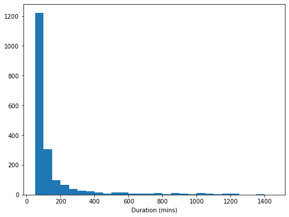

```python
binsize = 50
bins = np.arange(50, bikes_df_clean.duration_min.max() + binsize, binsize)

plt.figure(figsize=[8, 6])
plt.hist(data = bikes_df_clean, x = 'duration_min', bins=bins)
plt.xlabel('Duration (mins)')
plt.show();
```

> From the above chart, there is long tail in the duration distribution. it is a positively right skewed distribution hence, we need to plot it on a log scale.

```python
np.log10(bikes_df_clean.duration_min).describe()
```

```
count    174952.000000
mean          0.929673
std           0.305190
min           0.007179
25%           0.731051
50%           0.929419
75%           1.118926
max           3.148952
Name: duration_min, dtype: float64
```

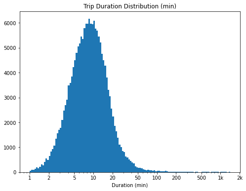

```python
log_binsize = 0.025
bins = 10 ** np.arange(0, np.log10(bikes_df_clean.duration_min.max()) + log_binsize, log_binsize)

plt.figure(figsize=[8,6])
plt.hist(data=bikes_df_clean, x = 'duration_min', bins=bins)
plt.xscale('log')
plt.xticks([1,2,5,10,20,50,100,200,500,1000,2000], [1,2,5,10,20,50,100,200,500,'1k','2k'])
plt.xlabel('Duration (min)')
plt.title('Trip Duration Distribution (min)')
plt.show()
```

> From the above, the Duration has a long-tailed distribution, with a few large durations at the end suggesting some strong outliers on the right. Based on the histogram, the peak duration falls between 5 minutes and 20 minutes and a smooth fall till around 200 minutes.

### Rides Frequency

```python
# converting days and hours into ordered categorical types

var_dict = {'start_day': ['Monday','Tuesday','Wednesday','Thursday','Friday', 'Saturday', 'Sunday'],
            'end_day': ['Monday','Tuesday','Wednesday','Thursday','Friday', 'Saturday', 'Sunday'],
            'start_hour': [str(i) for i in range(0,24)],
            'end_hour': [str(i) for i in range(0,24)]}

for var in var_dict:
    ordered_var = pd.api.types.CategoricalDtype(ordered = True,
                                                categories = var_dict[var])

    bikes_df_clean[var] = bikes_df_clean[var].astype(ordered_var)
```

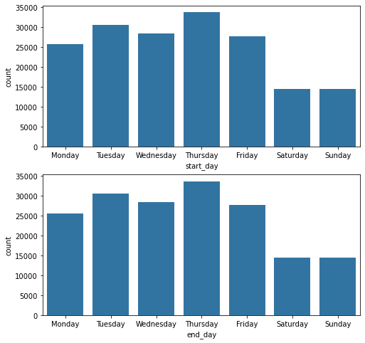

```python
# Rides frequency per days
fig, ax = plt.subplots(2, figsize = [8,8])

default_color = sb.color_palette()[0]
sb.countplot(data = bikes_df_clean, x = 'start_day', color = default_color,  ax = ax[0])
sb.countplot(data = bikes_df_clean, x = 'end_day', color = default_color,  ax = ax[1])
```

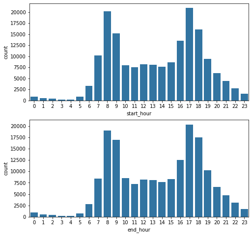

```python
# Rides frequency per hour
fig, ax = plt.subplots(2, figsize = [8,8])

color = sb.color_palette()[0]
sb.countplot(data = bikes_df_clean, x = 'start_hour', color = color, ax = ax[0])
sb.countplot(data = bikes_df_clean, x = 'end_hour', color = color, ax = ax[1])
```

> From the above charts, It is evident that high peaks are observed in the morning (8AM & 9AM) and the evenings at (4PM, 5PM & 6PM). This is shows that most trips are made before and after usual working (office) hours. It is therefore recorded that more trips were made at 5PM as compared to other hours while the 3AM & 4AM have the least trip records.

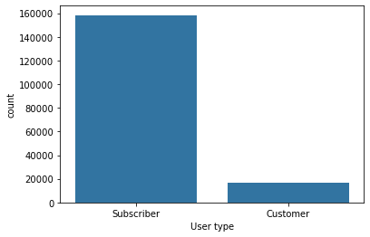

```python
# Rides frequency per user type
color = sb.color_palette()[0]
ax = sb.countplot(data = bikes_df_clean, x = 'user_type', color = color,
             order = bikes_df_clean.user_type.value_counts().index);
ax.set_xlabel('User type')
```

> From the above plots, it is evident that majority of the users are Subscribers with a substantial difference to Customers (First Plot).

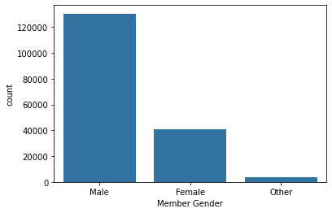

```python
# Rides frequency per member gender
color = sb.color_palette()[0]
ax = sb.countplot(data = bikes_df_clean, x = 'member_gender', color = color,
             order = bikes_df_clean.member_gender.value_counts().index);
ax.set_xlabel('Member Gender')
```

> It is evident, that majority of the users are Male with Substantial difference to Female users. An insignificant number of trips belog to Other gender type.

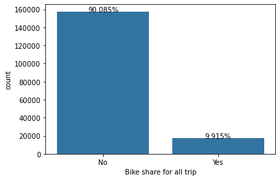

```python
# Rides frequency per Bikes share
color = sb.color_palette()[0]
ax = sb.countplot(data = bikes_df_clean, x = 'bike_share_for_all_trip', color = color,
             order = bikes_df_clean.bike_share_for_all_trip.value_counts().index);
ax.set_xlabel('Bike share for all trip')
total = len(bikes_df_clean)
for p in ax.patches:
    percentage = '{:.3f}%'.format(100 * p.get_height()/total)
    x = p.get_x() + p.get_width()/2
    y = p.get_height()+.05
    ax.annotate(percentage, (x, y),ha='center')
plt.show();
```

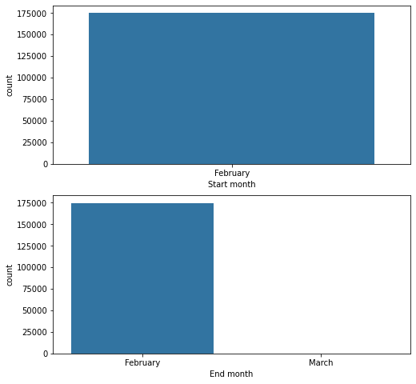

```python
# Rides frequency per month
fig, ax = plt.subplots(2, figsize = [8,8])

color = sb.color_palette()[0]
sb.countplot(data = bikes_df_clean, x = 'start_month',
             order=bikes_df_clean.start_month.value_counts(ascending=False).index,
             color = color, ax = ax[0])
sb.countplot(data = bikes_df_clean, x = 'end_month',order=bikes_df_clean.end_month.value_counts(ascending=False).index,
             color = color, ax = ax[1])

ax[0].set_xlabel('Start month')
ax[1].set_xlabel('End month')
```

> From the above, it is shown that all trips started and ended in February except for a very few in March

### Discuss the distribution(s) of your variable(s) of interest. Were there any unusual points? Did you need to perform any transformations?

> **Duration:** The duration distribution seemed higly aligned to the right at first suggesting a strong positively skewed distribution. This prompted us to plot the distribution using a log scale hence reducing the skew level. Later, it was evident that log scaling proved to be illuminating. It also made the distribution to become a unimodel and an approximate normal distribution.  
> **Time of day:** It was evident that the plots had peaks in the morning hours i.e. 8AM and 9AM and evening hours i.e. 4PM - 6PM. This showed that more trips were made before and after office/working hours. A substanstial decline in trips recorded was observed in hours after 6PM.  
> **Week days:** It was evident that more trips were made on Weekdays (Monday - Friday) as compared to weekends (Saturday - Sunday) and a high volume of trips were recorded on Thursdays.  
> **User type:** It was evident that majority of the users are Subscribers with a substantial difference to Customers.  
> **Gender:** It was evident, that majority of the users are Male with Substantial difference to Female users. An insignificant number of trips belog to Other gender type

### Of the features you investigated, were there any unusual distributions? Did you perform any operations on the data to tidy, adjust, or change the form of the data? If so, why did you do this?

> We discovered that the durations i.e. start_time and end_time were having incorrect data type. We later changed their data types to datetime using the pandas datetime convention function.  
> We also analysed a feature outside our area of interest i.e. Bikes Share for all trip and it was evident that majority of the users did not use bike share for their trips.

## Bivariate Exploration

```python
def plot_hist_bivariates(figsize, variables, main_variable, unicolored, ylabel, **kwargs):
    fig, ax = plt.subplots(len(variables), figsize = figsize)

    # ploting relationships
    count = 0
    for var in variables:
        color = 'Blues' if count % 2 == 0 else 'Greens'
        if unicolored and kwargs.get('type') == 'bar':
            sb.barplot(data = bikes_df_clean, x = var, y = main_variable, ax=ax[count], palette=color);
        elif not unicolored and kwargs.get('type') == 'bar':
            sb.barplot(data = bikes_df_clean, x = var, y = main_variable, ax=ax[count]);
#         if unicolored and kwargs.get('type') == 'box':
#             sb.boxplot(data = bikes_df_clean, x = var, y = main_variable, ax=ax[count], palette=color, showfliers=False);
#         elif not unicolored and kwargs.get('type') == 'box':
#             sb.boxplot(data = bikes_df_clean, x = var, y = main_variable, ax=ax[count], showfliers=False);
        elif unicolored:
            sb.countplot(data = bikes_df_clean, x = var, hue = main_variable, ax=ax[count], palette=color);
        else:
            sb.countplot(data = bikes_df_clean, x = var, hue = main_variable, ax=ax[count]);

        ax[count].set_ylabel(ylabel);
        x_label = var.replace('_', ' ').title();
        y_label = main_variable.replace('_', ' ').title();
        title =  'Relationship between ' + ylabel + ' and '+ x_label if kwargs.get('type') == 'bar' else  'Relationship between ' + x_label + ' and '+ y_label ;
        ax[count].set_xlabel(x_label);
        ax[count].set_title(title);
        count = count + 1

    fig.tight_layout();
```

#### Relationship between Time characteristics and User type

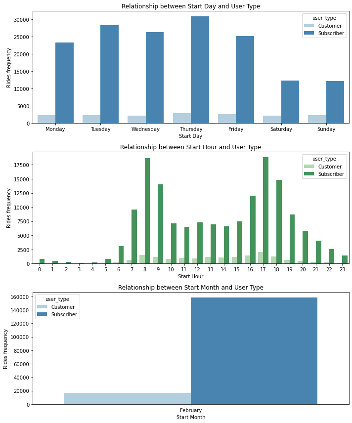

```python
# fig, ax = plt.subplots(3, figsize=[10, 12])

# sb.countplot(data = bikes_df_clean, x = 'start_day',
#                   hue = 'user_type', palette = 'Greens', ax = ax[0])
# ax[0].set_ylabel('Rides Frequency')
# ax[0].set_xlabel('Day of the week')
# ax[0].set_title('Relationship between Day of the week and User Type')
# ax[0].legend(title='User Type')

# sb.countplot(data = bikes_df_clean, x = 'start_hour',
#                   hue = 'user_type', palette = 'Blues', ax = ax[1])
# ax[1].set_ylabel('Rides Frequency')
# ax[1].set_xlabel('Start hour')
# ax[1].set_title('Relationship between Start hour and User Type')
# ax[1].legend(title='User Type')

# sb.countplot(data = bikes_df_clean, x = 'start_month',
#                   hue = 'user_type', palette = 'Greens', ax = ax[2])
# ax[2].set_ylabel('Rides Frequency')
# ax[2].set_xlabel('Start Month')
# ax[2].set_title('Relationship between Start Month and User Type')
# ax[2].legend(title='User Type')

# fig.tight_layout();

plot_hist_bivariates([10, 12], ['start_day', 'start_hour', 'start_month'], 'user_type', True, 'Rides frequency')
```

> From the above plots, Overall Subscribers have higher number of trips than customers across all times of the day. It is also evident that Morning hours i.e. 8 - 9AM and evening hours i.e. 4-6PM have the Most Subscriber bikers as compared to other hours. 5PM has the most 'Customer' bikers as compared to other times of the day.  
> It is also evident that, Subscribers have higher number of trips than Customers across all days of the week with Thursday as the Most Subscriber bikers and Customer bikers as compared to other days.  
> It is visible that, The month of February has the most Rides recorded with Subscribers as the Most recorded as compared to Customers

#### Relationship between Time characteristics and Member Gender

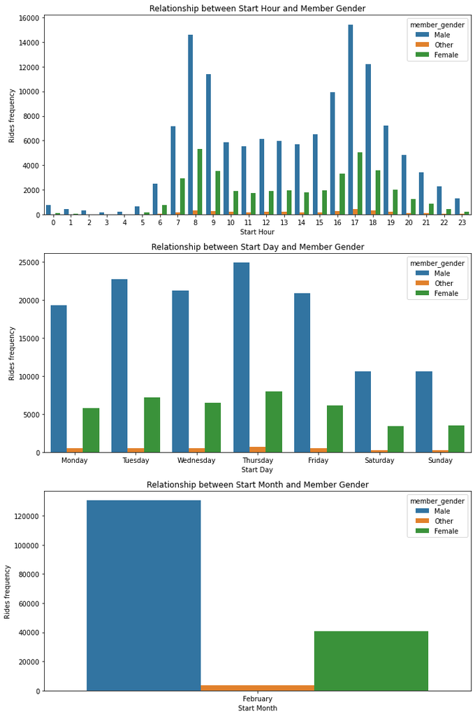

```python
plot_hist_bivariates([10, 15], ['start_hour', 'start_day', 'start_month'], 'member_gender', False, 'Rides frequency')
```

> From the above plots, it is evident that number of rides made are greater for Males than Females. Its also evident that Males are making more number of rides in weekdays rather than weekends.  
> More Male rides are recorded during peak hours 8-9AM and 4-6PM

#### Relationship between Ride duration and Rider characteristics

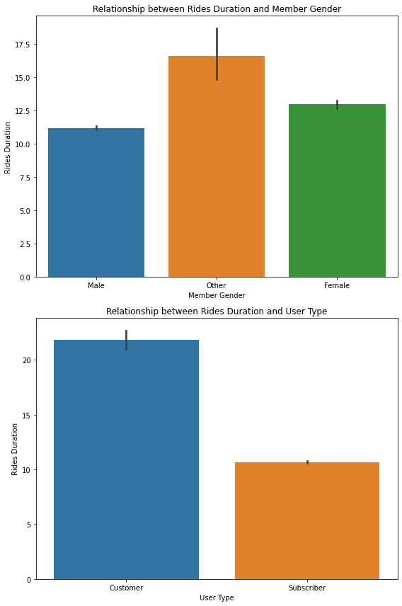

```python
plot_hist_bivariates([8, 12], [ 'member_gender', 'user_type'], 'duration_min', False, 'Rides Duration', type='bar')
```

```python
# plot_hist_bivariates([8, 12], [ 'member_gender', 'user_type'], 'duration_min', False, 'Rides Duration', type='box')
```

> From the above plots, In comparison to Ride frequency, Ride duration is higher for Females and other Genders than Males though Other Genders have the most Ride duration.  
> In a Similar manner, Ride duration is higher in Customers rather than Subscribers in comparison to ride frequency.

#### Relationship between Time and Ride Duration

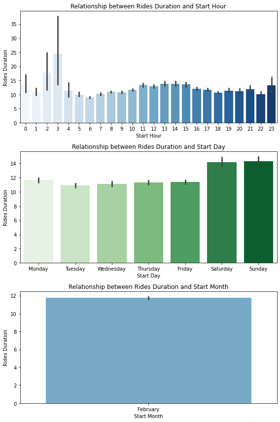

```python
plot_hist_bivariates([8, 12], [ 'start_hour','start_day', 'start_month'], 'duration_min', True, 'Rides Duration', type='bar')
```

> From the above plots, Weekends have more higher ride duration as compared to week days. It is also evident that the Relationship between time characteristics and ride duration totally differs from Relationship between time characteristics and ride frequency.

#### Relationship between Bike share and other categorical features

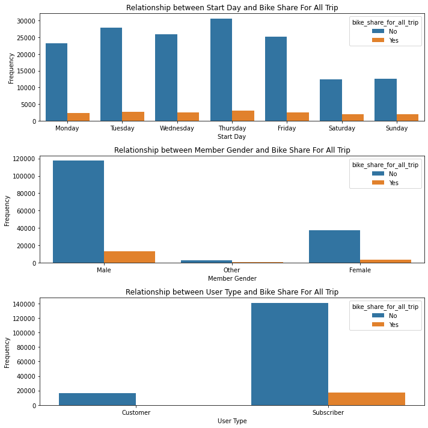

```python
plot_hist_bivariates([10, 10], [ 'start_day','member_gender', 'user_type'], 'bike_share_for_all_trip', False, 'Frequency')
```

> From the above plots, Most of the bikers do not use bike share for their entire trips though a few of the male riders use more bike share for trips as compared to female riders. In the same manner, Subscribed customers use more bike share than Casual customers

### Talk about some of the relationships you observed in this part of the investigation. How did the feature(s) of interest vary with other features in the dataset?

> **Ride Frequency:**

> From the above plots, it was observed that more rides were recorded on weekdays in the morning (8-9AM) and evening (4-6PM) hours

> In the peak hours, More Male riders were recorded as compared to other genders

> Most of the riders are member subscribers who commuted during the peak hours

> **Ride Duration:**

> From the plots, the peak times are weekends and at 3AM

> It is also evident that Customer are taking longer ride durations over member subscribers

### Did you observe any interesting relationships between the other features (not the main feature(s) of interest)?

> Out of all casual customers, all of them did not use bike share for their entire trip whereas a small proportion of the Subscribers used bike share for their entire trip.  
> Bikers who do not use bike share for their trips have a higher ride frequency across the week as compared to those who do use.

## Multivariate Exploration

#### Relationship between Time characteristics and User Type by Ride duration

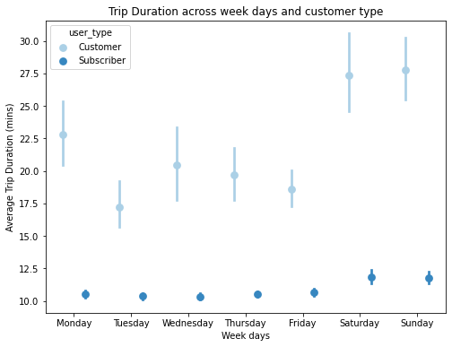

```python
fig = plt.figure(figsize=[8,6])
ax = sb.pointplot(data = bikes_df_clean, x = 'start_day',
                  y = 'duration_min', hue = 'user_type',
                  palette = 'Blues', linestyles = '', dodge = 0.4)
plt.title('Trip Duration across week days and customer type')
plt.ylabel('Average Trip Duration (mins)')
ax.set_yticklabels([], minor = True)
ax.set_xlabel('Week days')
plt.show();
```

#### Relationship between Gender and Day of the Week by Ride Duration

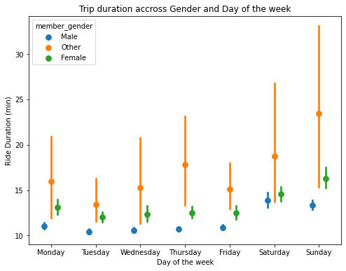

```python
fig = plt.figure(figsize=[8,6])
ax = sb.pointplot(data = bikes_df_clean, x = 'start_day', y = 'duration_min',
                  hue = 'member_gender', dodge=0.3, linestyles='')
plt.title('Trip duration accross Gender and Day of the week')
plt.ylabel('Ride Duration (min)')
plt.xlabel('Day of the week')
```

> From the above plot, it is evident that Other Gender made rides with the longest duration as compared to Males made the rides with the least duration. It is also noted Sunday is the day when the Other Gender made the longest trip duration

#### Relationship between Gender and User Type by Ride duration

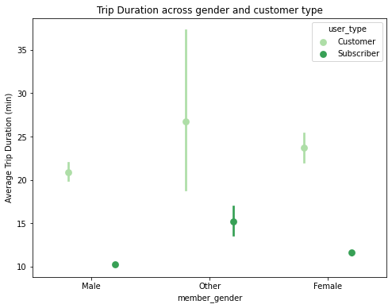

```python
fig = plt.figure(figsize=[8,6])
ax = sb.pointplot(data = bikes_df_clean, x='member_gender', y='duration_min', hue = 'user_type',
                 palette='Greens', linestyles='', dodge=0.4)
plt.title('Trip Duration across gender and customer type')
plt.ylabel('Average Trip Duration (min)')
ax.set_yticklabels([], minor=True)
plt.show();
```

> From the above, For both subscribers and customers, the Other gender group spent most duration followed by female as compared to the male

### Talk about some of the relationships you observed in this part of the investigation. Were there features that strengthened each other in terms of looking at your feature(s) of interest?

> From the above exploration, it was more evident that Other Casual customers are making trips with longer durations followed by Casual Female customers as compared to Male Subscribed riders who are making more rides with the least trip duration during weekdays.

### Were there any interesting or surprising interactions between features?

> No, there were no that significant surprising observations recorded. Ride frequency and Ride duration has contradictory relationship towards Riders characteristics. The relationship between time characteristics and ride duration totally differs from Relationship between time characteristics and ride frequency.

## Conclusions

> From the analysis made above, the following observations were made;

> Most trips were made on Thursdays and Tuesdays.

> Weekends had least trips recorded.

> Most trips about 90% were made by Subscribers.

> Most Trips were made by Male

> Weekend Trips had longer durations as compared to weekday trips

> Casual Customers spent more trip duration as compared to subscribers

> Female Customers made the most trip durations than Males

## Limitations

> Below are some of the limitations experienced during this analysis;

> Given the limited time, a partial analysis was made on the dataset. More variables can be explored and visualizations can be drawn from them.